# COVID-19 and Vaccine Confidence Data: Final Project EDA Long Form

Jamie Lee

10/25/2020

### Table of Contents

**Introduction**  
**Strong Agreement with Vaccine Confidence Measures Across Countries**  
**Median Age and Percentage of Different Agreement Levels with Vaccine Safety**  
**Average Agreement of Vaccine Importance Across Country from Scale of 1-4**  
**Different Levels of Agreement Regarding Vaccine Importance Across Countries**  
**Vaccine Importance and Total COVID-19 Cases Per Million**  
**New COVID-19 Cases Per Million Over Time and Stringency Index**  
**GDP Per Capita and Level of Agreement of Vaccine Compatibility with Religious Beliefs**  
**Different Religions and Vaccine Compatibility with Religious Beliefs**  
**Conclusion**  
**Citations**

### Introduction

For my final project, I worked with 2 main sets of data (that I also joined): the first was COVID-19 data containing reports about COVID-19 in countries all over the world across a range of time, up until 10/21/20. The second was vaccine confidence data which was regarding the confidence people in different countries have in vaccines. I broke down my vaccine confidence data set into 2 data sets, leading to 3 separate data sets I could use as well as 1 large joined data set. Although I am not interested in pursuing public health or medicine as a career, exploring these data sets holds a lot of importance to me because of the relevance that the COVID-19 pandemic and people’s vaccine confidence have to my life and to our world today. I sought to explore by comparing variables across the two data sets as well as within individual data sets.

```r
library(tidyverse)
library(janitor)
library(ggplot2)
library(lubridate)
```

```r
left_joined_data <- read_rds("data/data processed/Joined Data.rds")
vaccine_conf_1_data_new <- read_rds("data/data processed/Vaccine Confidence 1 Data.rds")
vaccine_conf_other <- read_rds("data/data processed/Vaccine Confidence Other Data.rds")
covid_data <- read_rds("data/data processed/Covid-19 Data.rds")
```

### Strong Agreement with Vaccine Confidence Measures Across Countries

I began by just looking at the vaccine confidence data - I was interested in exploring the percentage of people who strongly agree with vaccine effectiveness across different countries. Because there are a lot of countries in my data, I chose a mix that I thought would be interesting - for example, I included the United States and Korea since I’ve lived in both countries, and I looked up some countries with high and low vaccine confidence on the internet and included those. Some countries I just included “randomly” for the sake of having some geographic diversity.  
This plot below shows, across different countries, the percentage of people within the country who (from a scale of strongly agree, tend to agree, tend to disagree, strongly disagree, and do not know / did not respond) strongly agree that vaccines are effective. I was surprised by how different the percentages were for each country, and I was more surprised because the percentage for the USA was not as low as I had expected given how often we hear about anti-vaxxers in the news. However, perhaps I held that expectation of proportion of Americans being higher just because of the extent of media coverage.

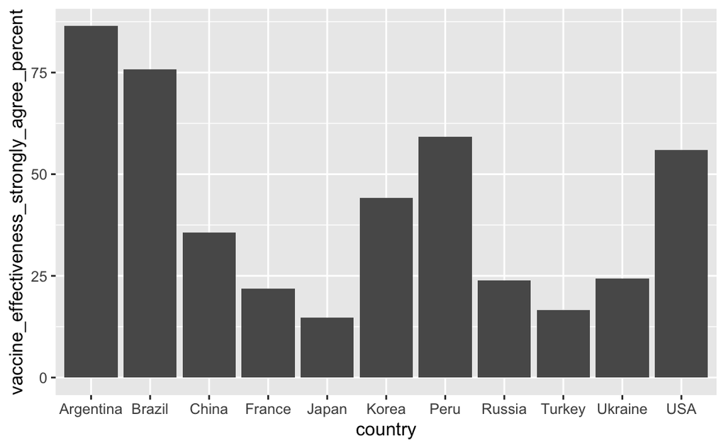

```r
vaccine_conf_1_data_new %>%
  group_by(country) %>%
  filter(country %in% c("USA", "Korea", "France", "Peru", "Brazil", "China",
        "Turkey", "Russia", "Ukraine", "Argentina", "Japan")) %>%
  select(country, vaccine_effectiveness_strongly_agree_percent) %>%
  ggplot() +
  geom_bar(aes(x = country, y = vaccine_effectiveness_strongly_agree_percent),
           na.rm = TRUE, stat = "identity")
```

This led me to wonder how different, if at all, these plots would look for other variables of vaccine confidence besides vaccine effectiveness. That led me to create the same plot for strong agreement with vaccine safety, vaccine importance, and vaccine compatibility with religious beliefs.  
This bar graph below shows the percentage of strong agreement that vaccines are safe across different countries. There were no drastic differences, although an interesting observation is that the percentages went down in comparison to vaccine effectiveness for a lot of countries. A potential reasoning that I had for why this might be is that, speaking from personal observation, it seems as if most anti-vaxxers are against vaccines because they think they are not safe, rather than because they are not effective.

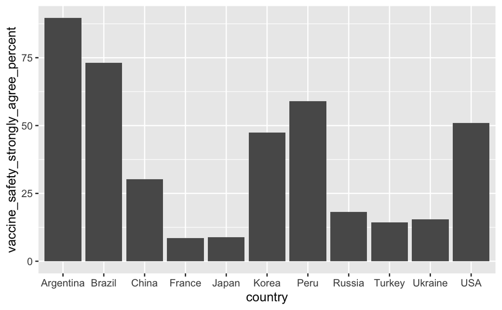

```r
vaccine_conf_1_data_new %>%
  group_by(country) %>%
  filter(country %in% c("USA", "Korea", "France", "Peru", "Brazil", "China",
                        "Turkey", "Russia", "Ukraine", "Argentina", "Japan")) %>%
  select(country, vaccine_safety_strongly_agree_percent) %>%
  ggplot() +
  geom_bar(aes(x = country, y = vaccine_safety_strongly_agree_percent),
           na.rm = TRUE, stat = "identity")
```

Here is the same plot below for vaccine importance. It shows the percentages of strong agreement that vaccines are important across the different countries.

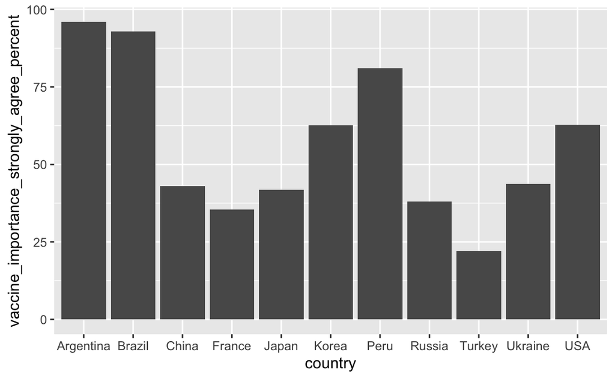

```r
vaccine_conf_1_data_new %>%
  group_by(country) %>%
  filter(country %in% c("USA", "Korea", "France", "Peru", "Brazil", "China",
                        "Turkey", "Russia", "Ukraine", "Argentina", "Japan")) %>%
  select(country, vaccine_importance_strongly_agree_percent) %>%
  ggplot() +
  geom_bar(aes(x = country, y = vaccine_importance_strongly_agree_percent),
           na.rm = TRUE, stat = "identity")
```

Lastly, here is the plot below for vaccine compatibility with religious beliefs. It shows the percentages of strong agreement that vaccines are compatible with religious beliefs across the different countries.

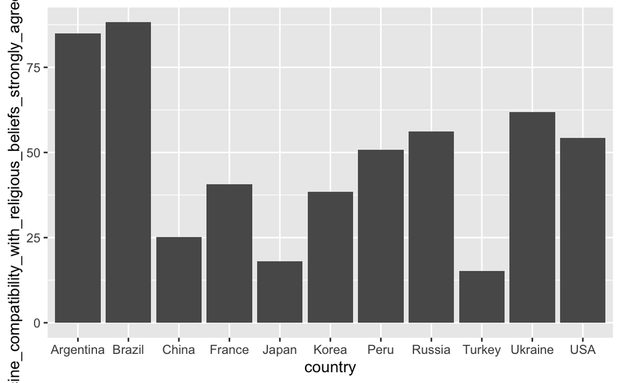

```r
vaccine_conf_1_data_new %>%
  group_by(country) %>%
  filter(country %in% c("USA", "Korea", "France", "Peru", "Brazil", "China",
        "Turkey", "Russia", "Ukraine", "Argentina", "Japan")) %>%
  select(country,
        vaccine_compatibility_with_religious_beliefs_strongly_agree_percent) %>%
  ggplot() +
  geom_bar(aes(x = country, y = vaccine_compatibility_with_religious_beliefs_strongly_agree_percent),
           na.rm = TRUE, stat = "identity")
```

Although I had some initial ideas of why the percentages might differ across the different variables regarding vaccine confidence, I would not be able to say the exact reasons why. Overall, I thought it was intriguing that a lot of countries varied more than expected among the different variables, although some countries (most notably Argentina and Brazil) stayed high for all variables and some countries (most notably Turkey) stayed quite low across all variables.

### Median Age and Percentage of Different Agreement Levels with Vaccine Safety

Next, I made a scatterplot, with each point representing a country in the data set, exploring if there was any correlation between median age of a country and the percentage of surveyed people in the country who strongly agree with vaccine safety.

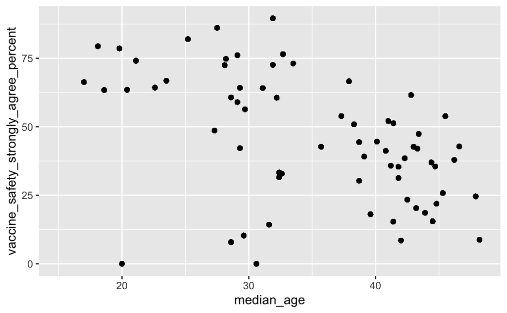

```r
left_joined_data %>%
  select(median_age, vaccine_safety_strongly_agree_percent) %>%
  ggplot(aes(x = median_age, y = vaccine_safety_strongly_agree_percent)) +
  geom_point(stat = "identity", na.rm = TRUE)
```

I noticed while looking at the plot that there were a few countries for which the percentage of strong agreement was 0 and thought that would be worth exploring further, hence the code below that filtered just for those countries which turned out to be Iraq and Israel.

```r
left_joined_data %>%
  group_by(location) %>%
  filter(vaccine_safety_strongly_agree_percent == 0) %>%
  summarise(country_median_age = mean(median_age),
            country_vaccine_safety_strongly_agree_percent = mean(vaccine_safety_strongly_agree_percent))
```

```
## # A tibble: 2 x 3
##   location country_median_age country_vaccine_safety_strongly_agree_percent
##   <chr>                 <dbl>                                         <dbl>
## 1 Iraq                   20                                               0
## 2 Israel                 30.6                                             0
```

I then decided to see if that would be any different for other levels of agreement with vaccine safety, so I did the same for the percentage of people who tend to agree as opposed to strongly agree, and it was again Iraq and Israel:

```r
left_joined_data %>%
  group_by(location) %>%
  filter(vaccine_safety_tend_to_agree_percent == 0) %>%
  summarise(country_median_age = mean(median_age),
            country_vaccine_safety_tend_to_agree_percent = mean(vaccine_safety_tend_to_agree_percent))
```

```
## # A tibble: 2 x 3
##   location country_median_age country_vaccine_safety_tend_to_agree_percent
##   <chr>                 <dbl>                                        <dbl>
## 1 Iraq                   20                                              0
## 2 Israel                 30.6                                            0
```

I checked the actual data set and realized that for all levels of agreement for all variables regarding vaccine confidence, all values were 0. This led me to filter out those countries, leading to this plot below. This shows a loosely negative correlation between median age and percent of strong agreement with vaccine safety which was the opposite of what I expected. I thought that stronger agreement that vaccines are safe could possibly be correlated with a higher median age, since people might have more protection against illnesses and live longer as a result.

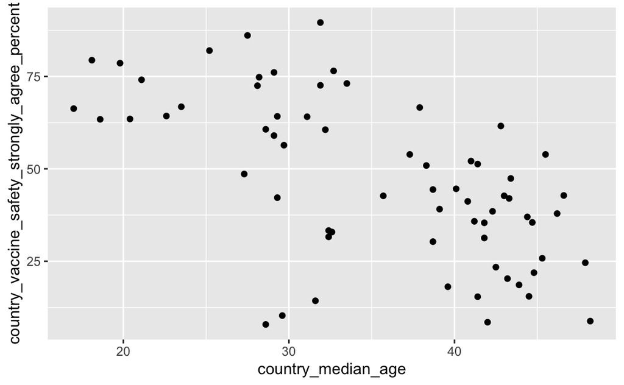

```r
left_joined_data %>%
  group_by(location) %>%
  filter(!vaccine_safety_strongly_agree_percent == 0) %>%
  summarise(country_median_age = mean(median_age),
            country_vaccine_safety_strongly_agree_percent = mean(vaccine_safety_strongly_agree_percent)) %>%
  ggplot(aes(x = country_median_age, y = country_vaccine_safety_strongly_agree_percent)) +
  geom_point(stat = "identity")
```

This led me to want to explore if the results would be any different for the percentage of people who agree as opposed to strongly agree, creating the same scatterplot but with “agree”. It is important to note that “agree” is part of an agree / disagree binary and is not part of the same scale as “strongly agree” (that scale, as stated earlier, is: strongly agree, tend to agree, tend to disagree, strongly disagree, and do not know / no response.) This plot overall shows that the percentages of people in these countries who agree with vaccine safety is higher than strongly agree. There is still a loosely negative correlation between the two variables.

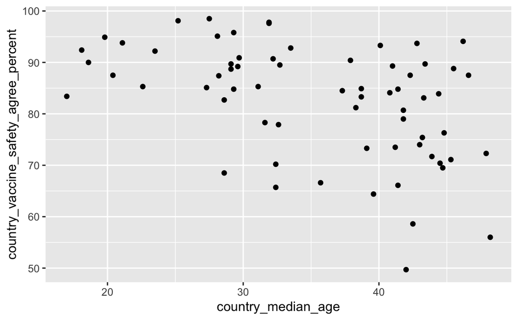

```r
left_joined_data %>%
  group_by(location) %>%
  filter(!vaccine_safety_agree_percent == 0) %>%
  summarise(country_median_age = mean(median_age),
            country_vaccine_safety_agree_percent = mean(vaccine_safety_agree_percent)) %>%
  ggplot(aes(x = country_median_age, y = country_vaccine_safety_agree_percent)) +
  geom_point(stat = "identity")
```

I then decided to explore “tend to agree” because I was curious how similar or different the results would be. This plot below was closer to the results I had expected. It shows a general positive correlation between median age and percentage of people who tend to agree with vaccine safety in these countries.

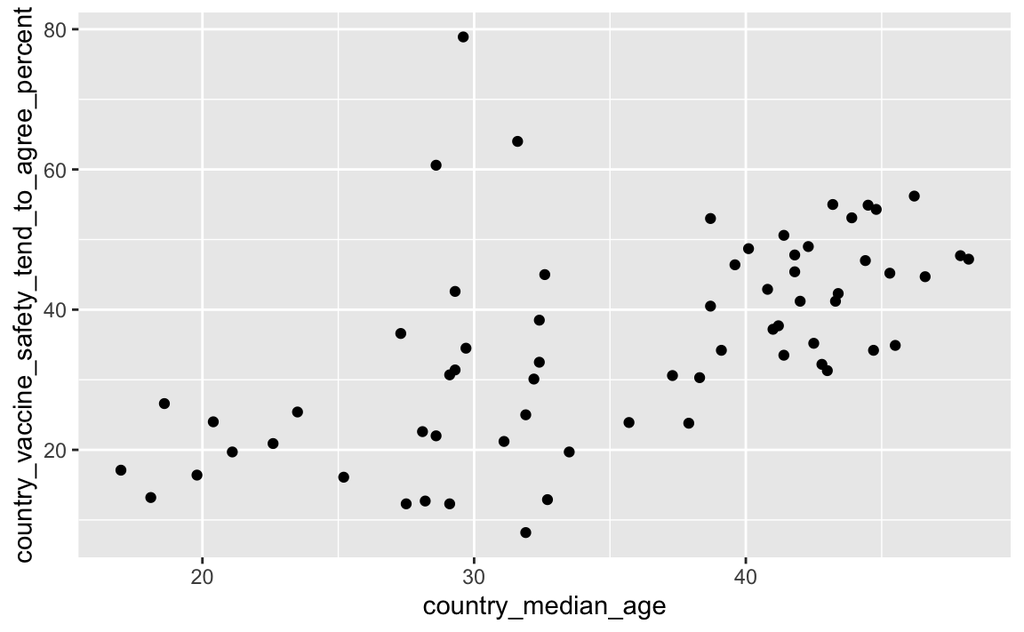

```r
left_joined_data %>%
  group_by(location) %>%
  filter(!vaccine_safety_tend_to_agree_percent == 0) %>%
  summarise(country_median_age = mean(median_age),
            country_vaccine_safety_tend_to_agree_percent = mean(vaccine_safety_tend_to_agree_percent)) %>%
  ggplot(aes(x = country_median_age, y = country_vaccine_safety_tend_to_agree_percent)) +
  geom_point(stat = "identity")
```

Below is the same plot but for percentage of vaccine disagreement. It is hard to say there is much correlation, although it could be said that there is very loose positive correlation.

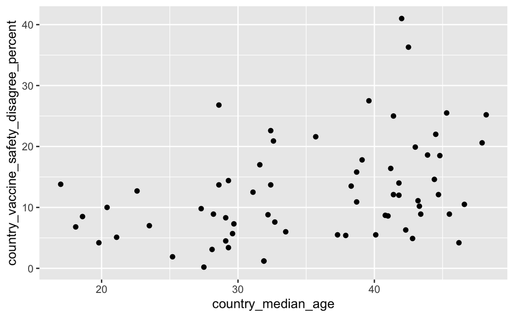

```r
left_joined_data %>%
  group_by(location) %>%
  filter(!vaccine_safety_disagree_percent == 0) %>%
  summarise(country_median_age = mean(median_age),
            country_vaccine_safety_disagree_percent = mean(vaccine_safety_disagree_percent)) %>%
  ggplot(aes(x = country_median_age, y = country_vaccine_safety_disagree_percent)) +
  geom_point(stat = "identity")
```

And lastly, this is the same plot but for percentage of people who tend to disagree with vaccine safety:

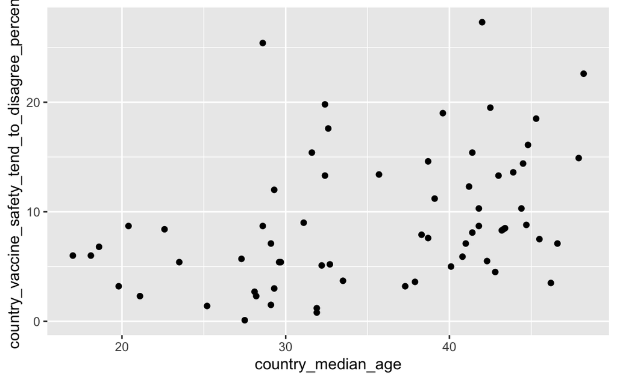

```r
left_joined_data %>%
  group_by(location) %>%
  filter(!vaccine_safety_tend_to_disagree_percent == 0) %>%
  summarise(country_median_age = mean(median_age),
            country_vaccine_safety_tend_to_disagree_percent = mean(vaccine_safety_tend_to_disagree_percent)) %>%
  ggplot(aes(x = country_median_age, y = country_vaccine_safety_tend_to_disagree_percent)) +
  geom_point(stat = "identity")
```

It is interesting to see that for percentages of those who disagree and tend to disagree, there are weak positive correlation, when “tend to agree” also had a positive correlation.

### Average Agreement of Vaccine Importance Across Country from Scale of 1-4

Next, I took the scale of strongly disagree, tend to disagree, tend to agree, and strongly agree, and I assigned a number of 1 to 4, respectively. (For example, strongly disagree would be a 1.) I did this because I was curious about the average numeric level of agreement that different countries had regarding vaccine importance. I created a function to calculate this, and then used it to calculate it for many different countries. I then created a tibble to organize this with two columns: country and average vaccine importance Lastly, I used that tibble to create a bar plot showing average vaccine importance across different countries. I was surprised that they all were above 3 - I thought that there might be some countries with lower averages (which may or may not be the case for other countries I did not include here). Similar countries are still on the lower side in a relative sense as observed with the prior plots from earlier in this report, such as France and Turkey, and same with the countries on the higher side such as Argentina and Brazil. However, the difference was not as drastic as I had expected.

```r
wt_avg_vaccine_imp <- function(weighted_base, strongly_agree, tend_to_agree, tend_to_disagree, strongly_disagree, dont_know_no_response) {
  new_base <- weighted_base - dont_know_no_response
  ((strongly_agree * 4) + (tend_to_agree * 3) + (tend_to_disagree * 2) + (strongly_disagree * 1)) / new_base
}

afghanistan_avg_vaccine_imp <- wt_avg_vaccine_imp(2080, 1585, 413, 67, 7, 7)
korea_avg_vaccine_imp <- wt_avg_vaccine_imp(1500, 939, 486, 68, 3, 5)
france_avg_vaccine_imp <- wt_avg_vaccine_imp(964, 341, 463, 73, 40, 47)
usa_avg_vaccine_imp <- wt_avg_vaccine_imp(1000, 628, 236, 43, 45, 48)
argentina_avg_vaccine_imp <- wt_avg_vaccine_imp(977, 933, 34, 0, 5, 1)
brazil_avg_vaccine_imp <- wt_avg_vaccine_imp(1985, 1845, 122, 8, 5, 5)
turkey_avg_vaccine_imp <- wt_avg_vaccine_imp(1027, 226, 746, 33, 4, 18)
japan_avg_vaccine_imp <- wt_avg_vaccine_imp(1157, 484, 470, 47, 7, 149)
china_avg_vaccine_imp <- wt_avg_vaccine_imp(1150, 494, 495, 142, 13, 6)
ukraine_avg_vaccine_imp <- wt_avg_vaccine_imp(492, 215, 189, 36, 24, 28)
finland_avg_vaccine_imp <- wt_avg_vaccine_imp(1127, 837, 232, 16, 6, 9)
ghana_avg_vaccine_imp <- wt_avg_vaccine_imp(995, 862, 84, 32, 8, 9)

tib_avg_vaccine_imp_by_country <- tibble(
  country = c("Afghanistan", "South Korea", "France", "USA", "Argentina",
          "Brazil", "Turkey", "Japan", "China", "Ukraine", "Finland", "Ghana"),
  avg_vaccine_importance = c(afghanistan_avg_vaccine_imp, korea_avg_vaccine_imp,
        france_avg_vaccine_imp, usa_avg_vaccine_imp, argentina_avg_vaccine_imp,
        brazil_avg_vaccine_imp, turkey_avg_vaccine_imp, japan_avg_vaccine_imp,
        china_avg_vaccine_imp, ukraine_avg_vaccine_imp, finland_avg_vaccine_imp,
        ghana_avg_vaccine_imp)
)

tib_avg_vaccine_imp_by_country
```

```
## # A tibble: 12 x 2
##    country     avg_vaccine_importance
##    <chr>                        <dbl>
##  1 Afghanistan                   3.72
##  2 South Korea                   3.58
##  3 France                        3.21
##  4 USA                           3.52
##  5 Argentina                     3.93
##  6 Brazil                        3.92
##  7 Turkey                        3.18
##  8 Japan                         3.42
##  9 China                         3.28
## 10 Ukraine                       3.28
## 11 Finland                       3.65
## 12 Ghana                         3.83
```

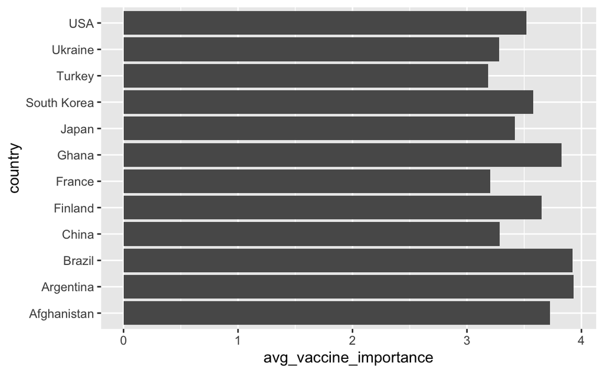

```r
tib_avg_vaccine_imp_by_country %>%
  ggplot(aes(x = country, y = avg_vaccine_importance)) +
  geom_bar(stat = "identity") +
  coord_flip()
```

### Different Levels of Agreement Regarding Vaccine Importance Across Countries

Next, I wanted to explore the percentage of people for each level of agreement with vaccine importance across a handful of different countries within one plot. I excluded “agree” and disagree" since that is a separate scale. It was interesting to see how strongly the Philippines and Saudi Arabia agree with vaccine importance relative to the other countries shown.

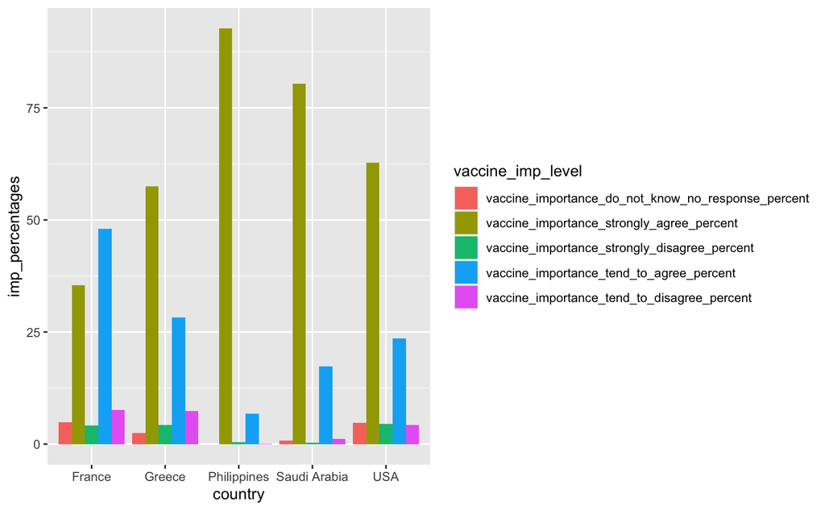

```r
levels_to_exclude <- c("vaccine_importance_agree_percent", "vaccine_importance_disagree_percent")

vaccine_conf_1_data_new %>%
  filter(country %in% c("USA", "Saudi Arabia", "Philippines", "France", "Greece")) %>%
  pivot_longer(cols = (starts_with("vaccine_importance") & ends_with("percent")), names_to = "vaccine_imp_level", values_to = "imp_percentages") %>%
  filter(!vaccine_imp_level %in% levels_to_exclude) %>%
  ggplot() +
  geom_bar(aes(x = country, y = imp_percentages, fill = vaccine_imp_level), position = "dodge", stat = "identity")
```

### Vaccine Importance and Total COVID-19 Cases Per Million

I moved onto exploring to see if there was any correlation between the percent of people who agree with vaccine importance and total cases per million of COVID-19 (I chose the date 10/21/20 which was the most recent date in my data set). I was interested in doing this because I was curious to see if there was any relationship between vaccine confidence and the severity of COVID-19’s impact on a country. I again filtered out those countries with values that are 0 (Iraq and Israel). There is not much correlation to see here in this scatterplot below, however.

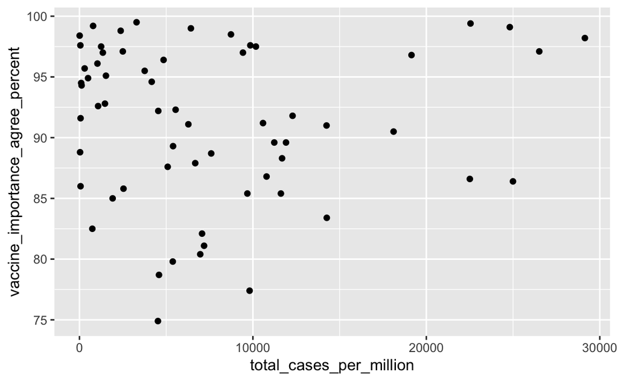

```r
left_joined_data %>%
  filter(date == "10/21/20", !vaccine_importance_agree_percent == 0) %>%
  ggplot(aes(x = total_cases_per_million, y = vaccine_importance_agree_percent)) +
  geom_point(na.rm = TRUE)
```

I moved on to trying the same but for the percentage of people who tend to agree with vaccine importance. Again, there was not much of a correlation.

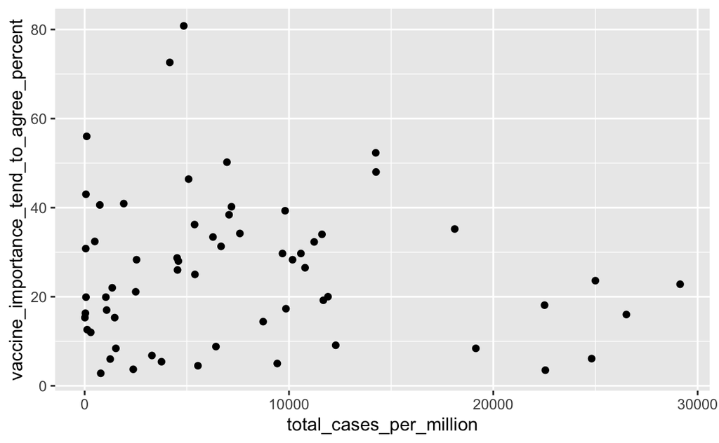

```r
left_joined_data %>%
  filter(date == "10/21/20", !vaccine_importance_tend_to_agree_percent == 0) %>%
  ggplot(aes(x = total_cases_per_million, y = vaccine_importance_tend_to_agree_percent)) +
  geom_point(na.rm = TRUE)
```

I did the same plot for strongly agree, tend to agree, and tend to disagree, respectively, as shown below. Although again not much correlation is present, there seems to be a more concentrated cluster where a country has relatively lower total cases per million and relatively higher agreement with vaccine importance / relatively lower disagreement.

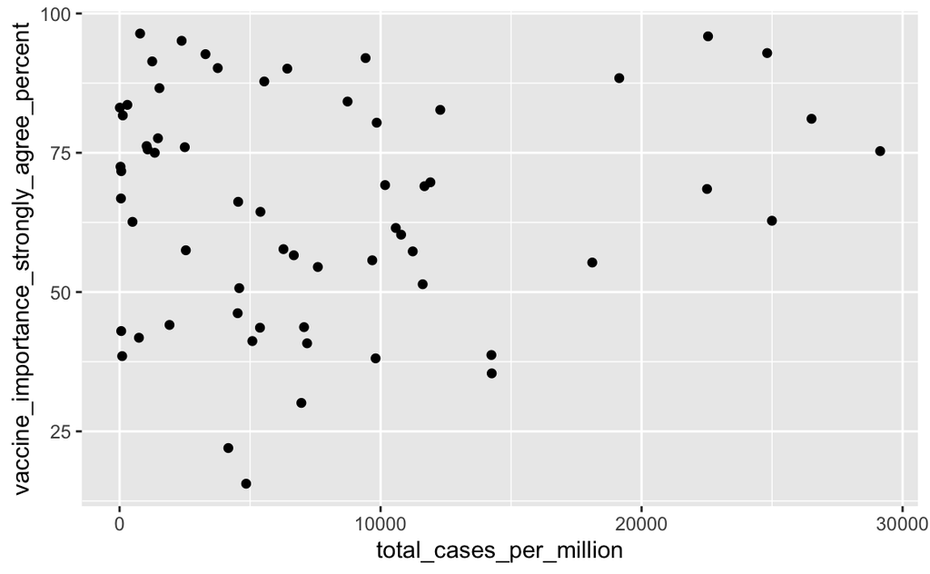

```r
left_joined_data %>%
  filter(date == "10/21/20", !vaccine_importance_strongly_agree_percent == 0) %>%
  ggplot(aes(x = total_cases_per_million, y = vaccine_importance_strongly_agree_percent)) +
  geom_point(na.rm = TRUE)
```

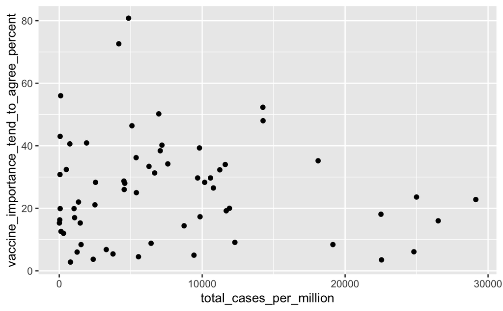

```r
left_joined_data %>%
  filter(date == "10/21/20", !vaccine_importance_tend_to_agree_percent == 0) %>%
  ggplot(aes(x = total_cases_per_million, y = vaccine_importance_tend_to_agree_percent)) +
  geom_point(na.rm = TRUE)
```

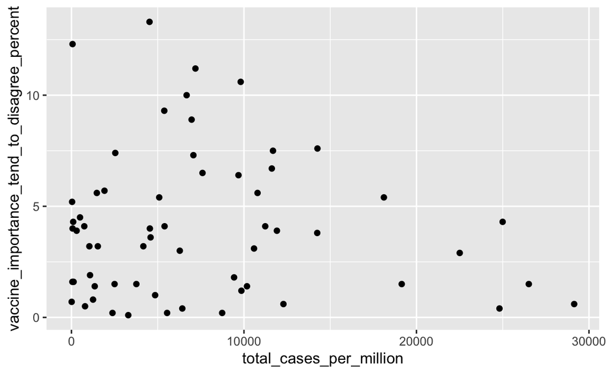

```r
left_joined_data %>%
  filter(date == "10/21/20", !vaccine_importance_tend_to_disagree_percent == 0) %>%
  ggplot(aes(x = total_cases_per_million, y = vaccine_importance_tend_to_disagree_percent)) +
  geom_point(na.rm = TRUE)
```

### New COVID-19 Cases Per Million Over Time and Stringency Index

Next, I created a plot demonstrating the number of new COVID-19 cases per million for the United States over time. Each point represents a day. I made the color of the points represent stringency index which is a numerical measure of how strict a country’s government was with COVID-19 precautionary measures. A higher stringency index means greater strictness. It is interesting to see the two peaks in number of new cases - the first near April, and the second around August. The most recent points are grey because the data was not available due to how recent it was (since I retrieved this data on 10/21/20.) It is also intriguing to see that the stringency index was higher with the first wave but became lower with the second wave which reached a higher record of new cases per million compared to the first wave.

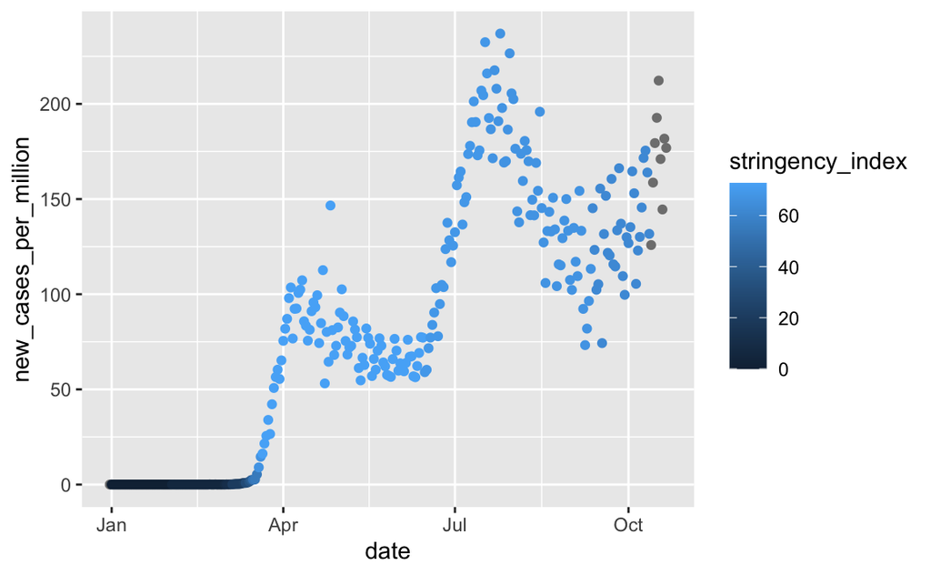

```r
left_joined_data %>%
  filter(location == "United States") %>%
  mutate(date = mdy(date)) %>%
  ggplot() +
  geom_point(aes(x = date, y = new_cases_per_million, color = stringency_index))
```

This made me curious about how the same plot would look for other countries, so here I tried out New Zealand - I remember reading in the news that they were successful in their efforts to fight COVID-19. The plot looks quite different - the first observation I had was that the new cases per million was much lower than that of the US. There was also one peak in April but it fell soon after. It is interesting to note that this peak was when the stringency index was highest - perhaps that was why the number of new cases per million fell quickly down.

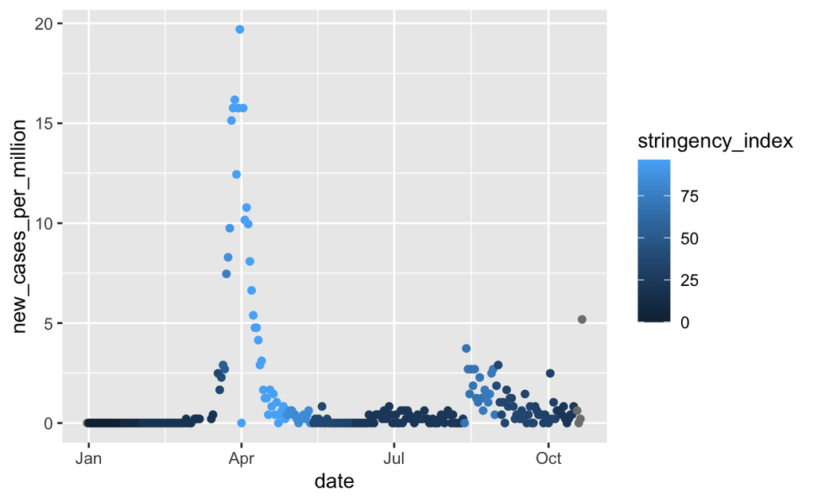

```r
left_joined_data %>%
  filter(location == "New Zealand") %>%
  mutate(date = mdy(date)) %>%
  ggplot() +
  geom_point(aes(x = date, y = new_cases_per_million, color = stringency_index))
```

Here is the same plot for Canada, below. This shows that Canada had one peak around May and this was when the stringency index was relatively high. The number of new cases per million seems to be going back up where the plot ends.

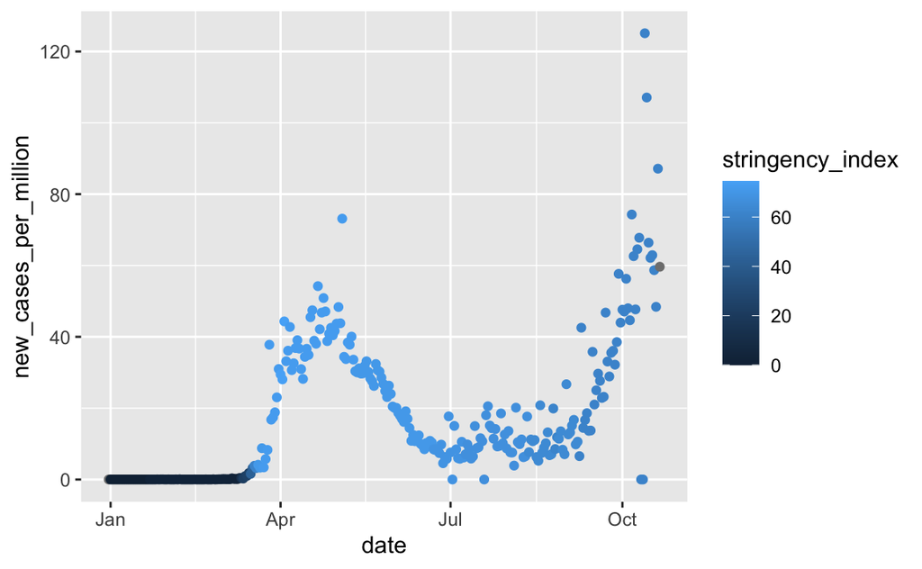

```r
left_joined_data %>%
  filter(location == "Canada") %>%
  mutate(date = mdy(date)) %>%
  ggplot() +
  geom_point(aes(x = date, y = new_cases_per_million, color = stringency_index))
```

### GDP Per Capita and Level of Agreement of Vaccine Compatibility with Religious Beliefs

Next, I wanted to explore correlations between countries’ GDP per capita with its percentage of people who tend to agree that vaccines are compatible with their religious beliefs. I again filtered out the countries that did not have data on this (referring again to Iraq and Israel.) There was not much to see here, but I chose to explore it because I did not expect a correlation but was curious to see if there would be some unexpected correlations within my data.

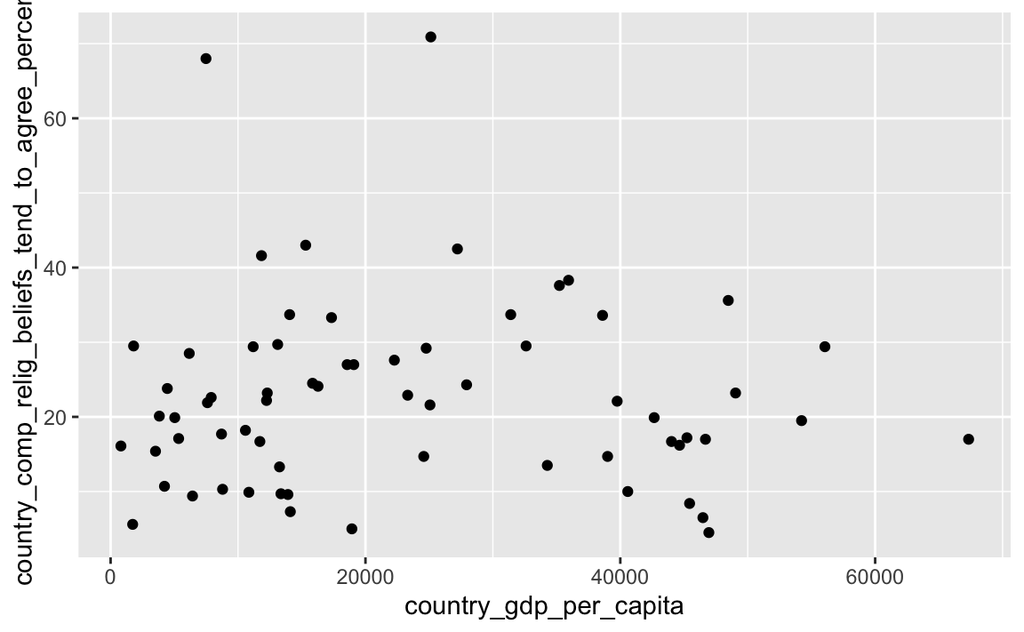

```r
left_joined_data %>%
  group_by(location) %>%
  filter(!vaccine_compatibility_with_religious_beliefs_tend_to_agree_percent == 0) %>%
  summarise(country_gdp_per_capita = mean(gdp_per_capita),
        country_comp_relig_beliefs_tend_to_agree_percent = mean(vaccine_compatibility_with_religious_beliefs_tend_to_agree_percent)) %>%
  ggplot(aes(x = country_gdp_per_capita, y = country_comp_relig_beliefs_tend_to_agree_percent)) +
  geom_point(stat = "identity")
```

I tried the same plot but for just “agree” as opposed to “tend to agree”. Again there was not much of a takeaway but nonetheless was interesting to see that there was not much correlation which is pretty much what I had expected.

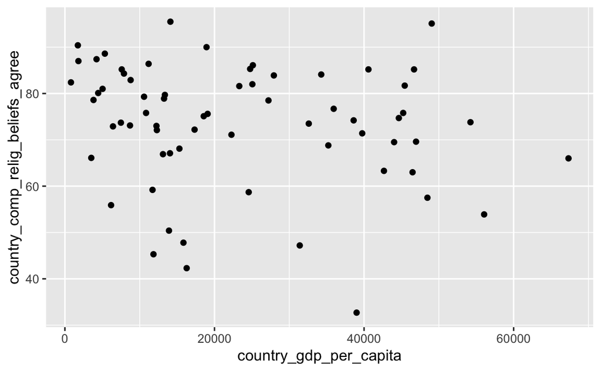

```r
left_joined_data %>%
  group_by(location) %>%
  filter(!vaccine_compatibility_with_religious_beliefs_agree_percent == 0) %>%
  summarise(country_gdp_per_capita = mean(gdp_per_capita),
            country_comp_relig_beliefs_agree = mean(vaccine_compatibility_with_religious_beliefs_agree_percent)) %>%
  ggplot(aes(x = country_gdp_per_capita, y = country_comp_relig_beliefs_agree)) +
  geom_point(stat = "identity")
```

### Different Religions and Vaccine Compatibility with Religious Beliefs

Lastly, I used a bar graph to explore vaccine compatibility with religious beliefs (from the scale of strongly agree to strongly disagree) across different religions. I was interested to compare across various religions as opposed to countries. It was quite surprising to see Christianity did not have the lowest vaccine compatibility with religious beliefs, given that, from the “anti-vaxxers” I have seen in news from US media using religion to oppose vaccines, the religion has often been a branch of Christianity. However, this plot shows that Buddhism is lowest in the percentage of those who strongly agree and highest in the percentage of people who tend to disagree, which was interesting given that I had never heard of vaccinations being incompatible with Buddhism and therefore never expected Buddhists to not strongly agree.

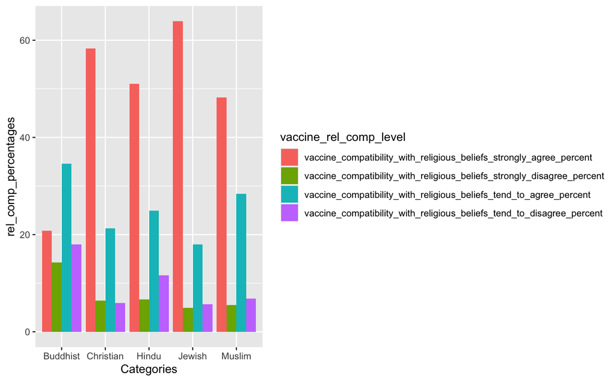

```r
colnames(vaccine_conf_other)[1] <- "Categories"

levels_to_exclude_rel_beliefs <- c("vaccine_compatibility_with_religious_beliefs_agree_percent",
                            "vaccine_compatibility_with_religious_beliefs_disagree_percent",
                            "vaccine_compatibility_with_religious_beliefs_do_not_know_no_response_percent")

vaccine_conf_other %>%
  filter(Categories %in% c("Christian", "Muslim", "Hindu", "Buddhist", "Jewish",
          "Athiest")) %>%
  pivot_longer(cols = (starts_with("vaccine_compatibility_with_religious_beliefs")
              & ends_with("percent")), names_to = "vaccine_rel_comp_level",
               values_to = "rel_comp_percentages") %>%
  filter(!vaccine_rel_comp_level %in% levels_to_exclude_rel_beliefs) %>%
  ggplot() +
  geom_bar(aes(x = Categories, y= rel_comp_percentages, fill = vaccine_rel_comp_level),
           position = "dodge", stat = "identity")
```

### Conclusion

Overall, there were many surprising and unexpected findings through this exploratory data analysis. Although there is certainly further exploration that can be done with these data sets, these were some beginning insights. Through this, I was able to explore COVID-19 data as well as levels of vaccine confidence in countries all over the world, both of which are increasingly relevant to my life and the current events I hear about every day.

### Citations

Mathieu, et.al, 2020. “covid-19 data”, https://github.com/owid/covid-19-data, Our World in Data.  
S., Claudia. 2020. “Vaccine Confidence Data - v2 via Gapminder”, https://docs.google.com/spreadsheets/d/1_EN4eAOS7zugaxQeEVYYVwFy3iFcBqzp5J6vvEGxJfI/edit#gid=501532268, World Bank, V2.